# DATA622 | Machine Learning and Big Data

Gabriella Martinez

4/23/2023

# Assignment 3

**Pre-work**  
Read the following articles:  
https://www.hindawi.com/journals/complexity/2021/5550344/  
https://www.ncbi.nlm.nih.gov/pmc/articles/PMC8137961/

- Search for academic content (at least 3 articles) that compare the use of decision trees vs SVMs in your current area of expertise.
- Perform an analysis of the dataset used in Homework #2 using the SVM algorithm.
- Compare the results with the results from previous homework.
- Answer questions, such as:
  - Which algorithm is recommended to get more accurate results?
  - Is it better for classification or regression scenarios?
  - Do you agree with the recommendations?
  - Why?

**Deliverable**  
1. Essay (minimum 500 words). Write a short essay explaining your selection of algorithms and how they relate to the data and what you are trying to do.  
2. Analysis using R or Python (submit code + errors + analysis as notebook or copy/paste to document). Include analysis R (or Python) code.

# Packages

```r
library(readr)
library(tidyverse)
library(tidymodels)
library(psych)
library(caret)
library(rpart)
library(rpart.plot)
library(corrplot)
library(RColorBrewer)
library(labelled)
library(ggplot2)
library(ggforce)
library(pROC)
library(mlbench)
library(ModelMetrics)
library(randomForest)
library(e1071)
```

# Load Data

```r
df1k <- read.csv("https://raw.githubusercontent.com/gabbypaola/DATA622/main/HW%201/1000%20Sales%20Records.csv")
```

# Exploratory Data Analysis

First, exploratory data analysis is conducted to get acquainted with the 1k Sales dataset selected from https://excelbianalytics.com/wp/downloads-18-sample-csv-files-data-sets-for-testing-sales/.

## Dimensions, Variable Types, Labels, Levels, and Frequencies

The `look_for()` function from the labelled package shows us each variable, their label (if available), column type, as well as the values for any factor type variables. The function produces no labels, and no values as none of the variables are coded as factor types.

```r
print("Dimensions")
```

```
## [1] "Dimensions"
```

```r
glimpse(df1k)
```

```
## Rows: 1,000
## Columns: 14
## $ Region         <chr> "Middle East and North Africa", "North America", "Middl~
## $ Country        <chr> "Libya", "Canada", "Libya", "Japan", "Chad", "Armenia",~
## $ Item.Type      <chr> "Cosmetics", "Vegetables", "Baby Food", "Cereal", "Frui~
## $ Sales.Channel  <chr> "Offline", "Online", "Offline", "Offline", "Offline", "~
## $ Order.Priority <chr> "M", "M", "C", "C", "H", "H", "H", "M", "H", "H", "M", ~
## $ Order.Date     <chr> "10/18/2014", "11/7/2011", "10/31/2016", "4/10/2010", "~
## $ Order.ID       <int> 686800706, 185941302, 246222341, 161442649, 645713555, ~
## $ Ship.Date      <chr> "10/31/2014", "12/8/2011", "12/9/2016", "5/12/2010", "8~
## $ Units.Sold     <int> 8446, 3018, 1517, 3322, 9845, 9528, 2844, 7299, 2428, 4~
## $ Unit.Price     <dbl> 437.20, 154.06, 255.28, 205.70, 9.33, 205.70, 205.70, 1~
## $ Unit.Cost      <dbl> 263.33, 90.93, 159.42, 117.11, 6.92, 117.11, 117.11, 35~
## $ Total.Revenue  <dbl> 3692591.20, 464953.08, 387259.76, 683335.40, 91853.85, ~
## $ Total.Cost     <dbl> 2224085.18, 274426.74, 241840.14, 389039.42, 68127.40, ~
## $ Total.Profit   <dbl> 1468506.02, 190526.34, 145419.62, 294295.98, 23726.45, ~
```

```r
print("Labels")
```

```
## [1] "Labels"
```

```r
look_for(df1k)
```

```
##  pos variable       label col_type values
##  1   Region         —     chr
##  2   Country        —     chr
##  3   Item.Type      —     chr
##  4   Sales.Channel  —     chr
##  5   Order.Priority —     chr
##  6   Order.Date     —     chr
##  7   Order.ID       —     int
##  8   Ship.Date      —     chr
##  9   Units.Sold     —     int
##  10  Unit.Price     —     dbl
##  11  Unit.Cost      —     dbl
##  12  Total.Revenue  —     dbl
##  13  Total.Cost     —     dbl
##  14  Total.Profit   —     dbl
```

As above, using the `unique()` and `length()` functions are used to investigate the geographic variables. There are also 7 Regions and 185 countries spanning the 1k dataset.

```r
unique(df1k$Region)
```

```
## [1] "Middle East and North Africa"      "North America"
## [3] "Asia"                              "Sub-Saharan Africa"
## [5] "Europe"                            "Central America and the Caribbean"
## [7] "Australia and Oceania"
```

```r
length(unique(df1k$Country))
```

```
## [1] 185
```

```r
table(df1k$Item.Type)[order(table(df1k$Item.Type),decreasing = TRUE)]
```

```
##
##       Beverages      Vegetables Office Supplies       Baby Food   Personal Care
##             101              97              89              87              87
##          Snacks          Cereal         Clothes            Meat       Household
##              82              79              78              78              77
##       Cosmetics          Fruits
##              75              70
```

```r
table(df1k$Sales.Channel)
```

```
##
## Offline  Online
##     520     480
```

## Variable Dependencies and Definitions

Below are the variable dependencies and definitions that are applicable to 1k dataset.

`Total.Cost` = `Units.Sold` * `Unit.Cost`  
`Total.Revenue` = `Units.Sold` * `Unit.Price`  
`Total.Profit` = `Total.Revenue` - `Total.Cost` (where `Total.Cost` and `Total.Revenue` depend on `Units.Sold`, `Unit.Cost`, and `Unit.Price`)

`Order.Priority`: C(Critical), H(High), M(Medium), and L(Low)

## Missing Data

Next the data is checked for any missing values.

The below shows no missing values for the 1k dataset.

```r
colSums(is.na(df1k))
```

```
##         Region        Country      Item.Type  Sales.Channel Order.Priority
##              0              0              0              0              0
##     Order.Date       Order.ID      Ship.Date     Units.Sold     Unit.Price
##              0              0              0              0              0
##      Unit.Cost  Total.Revenue     Total.Cost   Total.Profit
##              0              0              0              0
```

## Distributions

```r
#select numeric columns 1k
df1k_n <- df1k %>%
  keep(is.numeric)

#stats
describe(df1k_n, fast=TRUE) %>%
  select(c(-vars,-n))
```

```
##                       mean           sd         min          max        range
## Order.ID      549681324.74 257133358.84 1.02928e+08 995529830.00 892601824.00
## Units.Sold         5053.99      2901.38 1.30000e+01      9998.00      9985.00
## Unit.Price          262.11       216.02 9.33000e+00       668.27       658.94
## Unit.Cost           184.97       175.29 6.92000e+00       524.96       518.04
## Total.Revenue   1327321.84   1486514.56 2.04325e+03   6617209.54   6615166.29
## Total.Cost       936119.23   1162570.75 1.41675e+03   5204978.40   5203561.65
## Total.Profit     391202.61    383640.19 5.32610e+02   1726181.36   1725648.75
##                       se
## Order.ID      8131270.76
## Units.Sold         91.75
## Unit.Price          6.83
## Unit.Cost           5.54
## Total.Revenue   47007.72
## Total.Cost      36763.72
## Total.Profit    12131.77
```

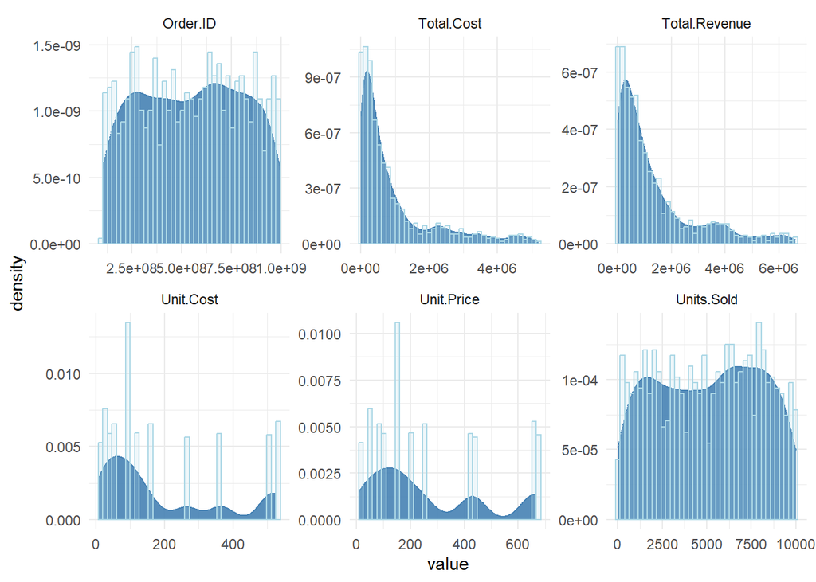

```r
#distributions
df1k_n %>%
  gather(variable, value, 1:6) %>%
  ggplot(aes(value)) +
    facet_wrap(~variable, scales = "free") +
    geom_density(fill = "steelblue", alpha=0.9, color="steelblue") +
    geom_histogram(aes(y=after_stat(density)), alpha=0.2, fill = "lightblue",
                   color="lightblue", position="identity",bins = 40) +
    theme_minimal()
```

## Correlations

Subsequently, the correlations between numeric variables are examined. It is important to investigate the correlations between the independent variables to avoid multicollinearity. Multicollinearity occurs when two or more independent variables are highly correlated to one another. When two (or more) independent variables are highly correlated one cannot individually determine the impact of individual variables on the dependent variable.

Multicollinearity can be a problem in a regression model when using algorithms such as OLS (ordinary least squares). This is because the estimated regression coefficients become unstable and difficult to interpret in the presence of multicollinearity.

When multicollinearity is present, the estimated regression coefficients may become large and unpredictable, leading to unreliable inferences about the effects of the predictor variables on the response variable. Therefore, it is important to check for multicollinearity and consider using other regression techniques that can handle this problem, such as ridge regression or principal component regression or make a decision about dropping highly correlated independent variables entirely.

Variables with weak correlation (i.e., 0<=|r|<0.3) [^1] between `Unit.Price`,`Unit.Cost`, and `Units.Sold`. Moderate correlation (i.e., 0.3≤|r|<0.7) can be seen between `Total.Profit`, `Total.Revenue`, `Total.Cost` and `Units.Sold` as well as between `Unit.Price`, `Unit.Cost` and `Total.Profit`. High correlation (i.e., |r|>=0.7) can be seen in the remaining pairs, especially between `Unit.Price` and `Unit.Cost`, `Total.Profit` and `Total.Revenue`, `Total.Cost` and `Total.Revenue`.

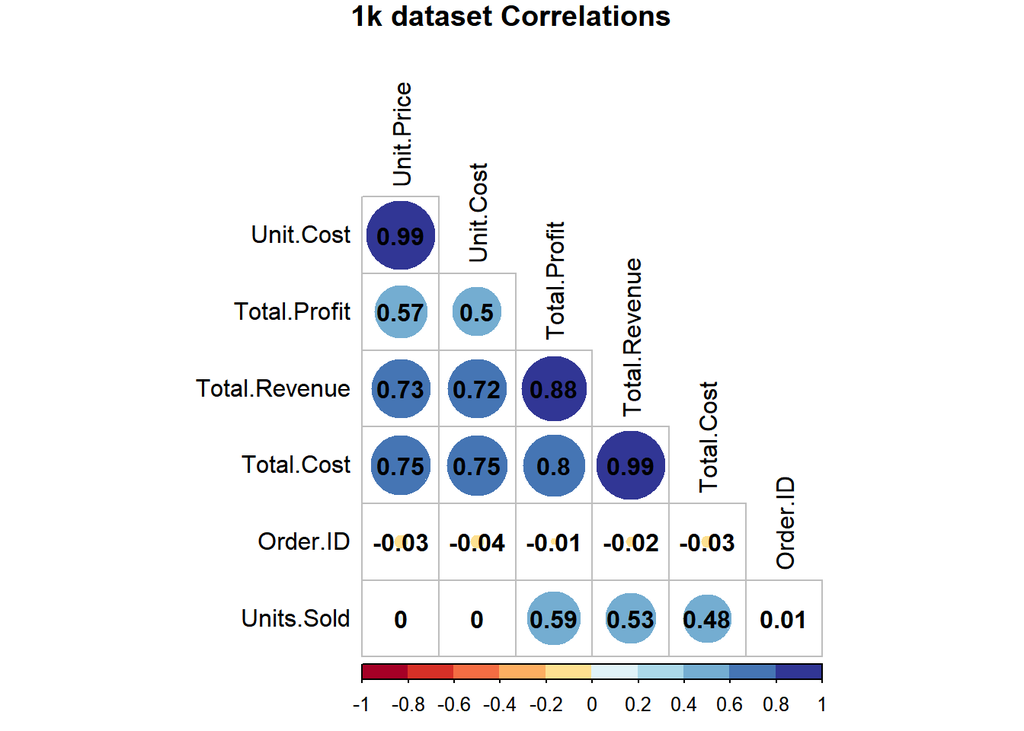

```r
cor(df1k_n) %>%
  corrplot(tl.col = 'black', diag=FALSE, type="lower",
           order="hclust", addCoef.col = "black",
           title="1k dataset Correlations",mar=c(0,0,1,0),
           col=brewer.pal(n=10, name="RdYlBu"))
```

## VIF Scores

Another detection method for multicoliniarity is through the use of the VIF (Variance Inflation Factor) score. Although correlation matrix and scatter plots can also be used to find multicollinearity, their findings only show the bivariate relationship between the independent variables. VIF is preferred as it can show the correlation of a variable with a group of other variables. The variance inflation factor (or VIF), measures how much the variance of a regression coefficient is inflated due to multicollinearity in the model. The smallest possible value of VIF is one (absence of multicollinearity). As a rule of thumb, a VIF value that exceeds 5 or 10 indicates a problematic amount of collinearity. [^2]

Below the VIF scores are calculated for the 1k dataset.

```r
set.seed(145)

training.samples0 <- df1k_n$Total.Revenue %>%
  createDataPartition(p = 0.8, list = FALSE)
train.data  <- df1k_n[training.samples0, ]
test.data <- df1k_n[-training.samples0, ]

# Build the model
#%>% select(c(-Total.Profit,-Total.Cost, -Unit.Price))
model<- lm(Total.Revenue~., data=train.data )

summary(model)
```

```
##
## Call:
## lm(formula = Total.Revenue ~ ., data = train.data)
##
## Residuals:
##        Min         1Q     Median         3Q        Max
## -2.941e-08 -7.460e-11  8.360e-11  2.510e-10  5.544e-09
##
## Coefficients:
##                Estimate Std. Error    t value Pr(>|t|)
## (Intercept)  -2.316e-09  2.248e-10 -1.030e+01   <2e-16 ***
## Order.ID      2.719e-19  2.063e-19  1.318e+00    0.188
## Units.Sold    2.746e-13  3.267e-14  8.407e+00   <2e-16 ***
## Unit.Price   -8.032e-13  3.207e-12 -2.500e-01    0.802
## Unit.Cost     1.756e-12  3.942e-12  4.460e-01    0.656
## Total.Cost    1.000e+00  1.561e-16  6.407e+15   <2e-16 ***
## Total.Profit  1.000e+00  5.365e-16  1.864e+15   <2e-16 ***
## ---
## Signif. codes:  0 '***' 0.001 '**' 0.01 '*' 0.05 '.' 0.1 ' ' 1
##
## Residual standard error: 1.509e-09 on 793 degrees of freedom
## Multiple R-squared:      1,  Adjusted R-squared:      1
## F-statistic: 1.295e+32 on 6 and 793 DF,  p-value: < 2.2e-16
```

```r
# Make predictions
predictions0 <- model %>% predict(test.data)
# Model performance
data.frame(
  MAE = mae(predictions0, test.data$Total.Revenue),
  RMSE = RMSE(predictions0, test.data$Total.Revenue),
  R2 = R2(predictions0, test.data$Total.Revenue)
)
```

```
##            MAE         RMSE R2
## 1 1.158876e-09 1.471262e-09  1
```

The 1k dataset exhibits high VIF values, confirming the multicoliniairty detected between the predictor variables in the correlation plot.

```r
car::vif(model)
```

```
##     Order.ID   Units.Sold   Unit.Price    Unit.Cost   Total.Cost Total.Profit
##     1.004224     3.130544   172.610738   171.728971    11.558110    14.749830
```

# Preprocessing

## Variable Type Conversions

Variable types are converted to ensure the models created use the correct type of variables. Variable conversion also aids in the preprocessing by ensuring originally numeric variables such as `Order.ID` are not inadvertently normalized or used in the modelling stage. There are a number of advantages to converting categorical variables to factor variables. Perhaps the most important advantage is that they can be used in statistical modeling where they will be implemented correctly, i.e., they will then be assigned the correct number of degrees of freedom. [^3]

```r
df1k[['Order.Date']] <- as.Date(df1k[['Order.Date']], "%m/%d/%Y")
df1k[['Ship.Date']] <- as.Date(df1k[['Ship.Date']], "%m/%d/%Y")

df1k[['Sales.Channel']] <- as.factor(df1k[['Sales.Channel']])

df1k[['Order.Priority']] <- as.factor(df1k[['Order.Priority']])

df1k[['Item.Type']] <- as.factor(df1k[['Item.Type']])

df1k[['Region']] <- as.factor(df1k[['Region']])

df1k[['Country']] <- as.factor(df1k[['Country']])

df1k[['Order.ID']] <- as.character(df1k[['Order.ID']])
```

```r
levels(df1k$Sales.Channel)
```

```
## [1] "Offline" "Online"
```

## Scaling

Next, the data is scaled in preparation for modelling. [^4] When variables are measured at different scales, they often do not contribute equally to the analysis. For example, if the values of one variable range from 0 to 100,000 and the values of another variable range from 0 to 100, the variable with the larger range will be given a larger weight in the analysis. By scaling the variables, we can be sure that each variable contributes equally to the analysis and reduce the variance effect.

```r
#apply preprocessing and generate transformed values
df1k_norm<-predict(preProcess(df1k, method=c("center", "scale")),df1k)
```

```r
#stats
df1k_norm %>%
  keep(is.numeric) %>%
  describe(fast=TRUE) %>%
  select(-c(vars,n))
```

```
##               mean sd   min  max range   se
## Units.Sold       0  1 -1.74 1.70  3.44 0.03
## Unit.Price       0  1 -1.17 1.88  3.05 0.03
## Unit.Cost        0  1 -1.02 1.94  2.96 0.03
## Total.Revenue    0  1 -0.89 3.56  4.45 0.03
## Total.Cost       0  1 -0.80 3.67  4.48 0.03
## Total.Profit     0  1 -1.02 3.48  4.50 0.03
```

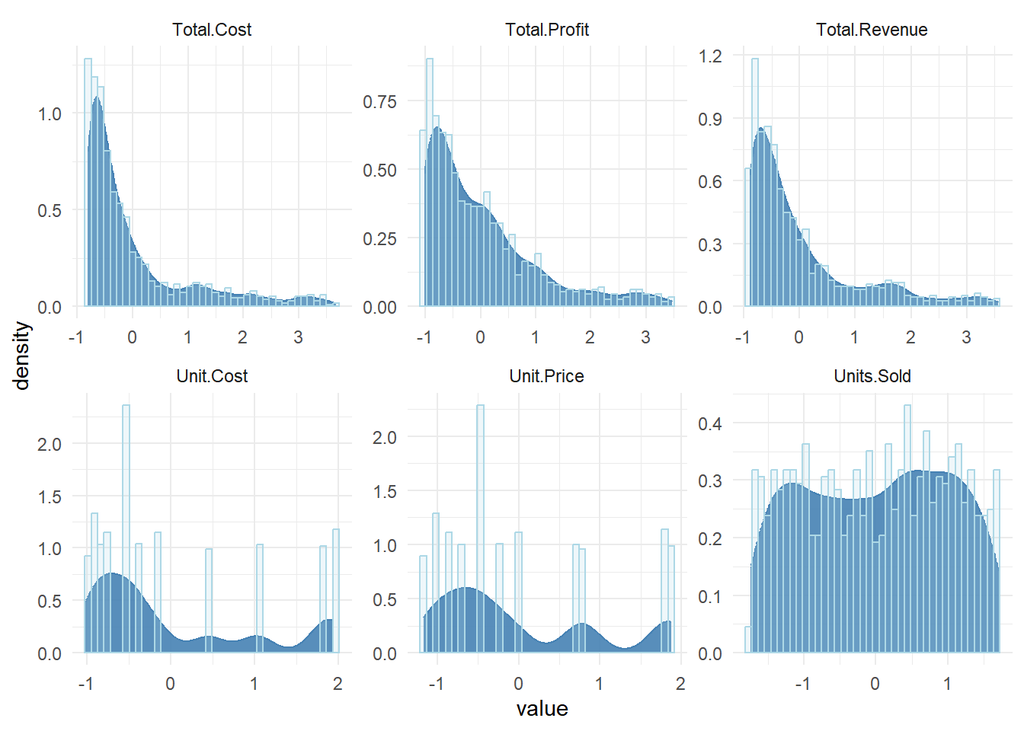

```r
#distribution
df1k_norm %>%
  keep(is.numeric) %>%
  gather(variable, value, 1:6) %>%
  ggplot(aes(value)) +
    facet_wrap(~variable, scales = "free") +
    geom_density(fill = "steelblue", alpha=0.9, color="steelblue") +
    geom_histogram(aes(y=after_stat(density)), alpha=0.2, fill = "lightblue",
                   color="lightblue", position="identity", bins = 40) +
    theme_minimal()
```

## Feature Selection

Feature Selection is the method of reducing the input variable to your model by using only relevant data and getting rid of noise in data. It is primarily focused on removing non-informative or redundant predictors from the model.

```r
df1k_norm <- df1k_norm %>%
  select(-c(Country,Order.ID,)) #Unit.Price, Unit.Cost, Total.Cost, Total.Profit
```

# Models

## SVM Regression Model

R package `e1071` is required to call the `svm()` function. The scaled data is used to create the model using all predictor variables with exception to `Country` and `Order.ID` which were removed in the feature selection stage. The `type` parameter is specified as `eps-regression` to ensure the model is created appropriately for the `Total.Revenue` variable.

The R code for the SVM model is as follows:

```r
set.seed(973)

df1k_norm1 <- df1k_norm

#split
training.samples <- df1k_norm1$Total.Revenue %>%
  createDataPartition(p = 0.8, list = FALSE)

train  <- df1k_norm1[training.samples, ]
test <- df1k_norm1[-training.samples, ]

svm_model<-svm(formula = Total.Revenue ~ ., data = train, type = 'eps-regression') #, kernel='linear'

print(svm_model)
```

```
##
## Call:
## svm(formula = Total.Revenue ~ ., data = train, type = "eps-regression")
##
##
## Parameters:
##    SVM-Type:  eps-regression
##  SVM-Kernel:  radial
##        cost:  1
##       gamma:  0.03448276
##     epsilon:  0.1
##
##
## Number of Support Vectors:  76
```

From the above, it can be seen that the default kernel used in creating the SVM model is the radial kernel.

### Predictions

```r
#use model to make predictions on test data
predictions_ <- predict(svm_model, newdata = test) %>%
  bind_cols(test)

predictions_$...1 <- as.numeric(predictions_$...1)
```

### Model Performance

```r
g <- data.frame(Model = "SVM",
#mean absolute error
MAE = mae(predictions_$Total.Revenue, predictions_$...1),
#rmse Root Mean Squared Error
RMSE = rmse(predictions_$Total.Revenue, predictions_$...1),
#r squared
R2 = R2(predictions_$Total.Revenue, predictions_$...1)
)

g
```

```
##   Model        MAE       RMSE      R2
## 1   SVM 0.04563273 0.06034851 0.99654
```

# Model Comparison

```r
rbind(a,b,c,d,e,f,g)
```

```
##                        Model        MAE       RMSE        R2
## 1   Simple Linear Regression 0.55942748 0.75997329 0.2960062
## 2 Multiple Linear Regression 0.30052049 0.40520126 0.8063358
## 3            Decision Tree 1 0.12838922 0.17445923 0.9688184
## 4            Decision Tree 2 0.14830362 0.19035855 0.9677867
## 5              Random Forest 0.02363693 0.04324748 0.9986716
## 6        Tuned Random Forest 0.01391962 0.02615845 0.9993922
## 7                        SVM 0.04563273 0.06034851 0.9965400
```

# Essay

Support Vector Regression (SVR) works on similar principles as Support Vector Machine (SVM) classification. One can say that SVR is the adapted form of SVM when the dependent variable is numerical rather than categorical. A major benefit of using SVR is that it is a non-parametric technique. Unlike simple linear regression, whose results depend on Gauss-Markov assumptions, the output model from SVR does not depend on distributions of the underlying dependent and independent variables. Instead the SVR technique depends on kernel functions. Another advantage of SVR is that it permits for construction of a non-linear model without changing the explanatory variables, helping in better interpretation of the resultant model. The basic idea behind SVR is not to care about the prediction as long as the error (ϵi) is less than certain value. This is known as the principle of maximal margin. This idea of maximal margin allows viewing SVR as a convex optimization problem. The regression can also be penalized using a cost parameter, which becomes handy to avoid over-fit. SVR is a useful technique that provides the user with high flexibility in terms of distribution of underlying variables, relationship between independent and dependent variables and the control on the penalty term. SVR technique relies on kernel functions to construct the model. The commonly used kernel functions are: a) Linear, b) Polynomial, c) Sigmoid and d) Radial Basis. While implementing SVR technique, the user needs to select the appropriate kernel function. The selection of the kernel function is tricky and requires optimization techniques for the best selection.

# References

[^1]: https://www.ncbi.nlm.nih.gov/pmc/articles/PMC4888898/
[^2]: http://www.sthda.com/english/articles/39-regression-model-diagnostics/160-multicollinearity-essentials-and-vif-in-r/
[^3]: https://stats.oarc.ucla.edu/r/modules/factor-variables/#:~:text=Perhaps%20the%20most%20important%20advantage,many%20different%20types%20of%20graphics.
[^4]: https://www.statology.org/how-to-normalize-data-in-r/